# AP Computer Manipulation

Sam Eckhardt

Monday, November 10, 2014

# Summary

This data is from the College Board, and was collected by Barbara Ericson. The data contains information on the pass rates for the AP Computer Science test, which happens every May. The data also includes pass rates by race, including Hispanic and Black, as well as the overall pass rate. The data is split into three sheets; One includes state data on a year by year basis, and the other two is more specific data for the years of 2013 and 2012. Our Goal is to summarise some of this data, provide some insightful comparisons, and find out what this data really shows about pass rates.

## GoogleVis

We will be using googleVis for some of our graphs. GoogleVis is a package within R that allows for the easy creation of graphs that you can select and deselect certain parts and factors in it, as well as other visualizations. You will be able to see for yourself what googleVis is capable of as you go through our presentation. As well, we will be using ggplot2 for our static graphs.

```r
suppressPackageStartupMessages(library(googleVis))
library(ggplot2)
library(gridExtra)
library(gtable)
library(ggmap)
library(reshape2)
library(scales)
library(dplyr)
setwd("~/SCHOOL/Senior Fall/MKTG 489/AP-Computer-Repository")
APcomputercleaned2013 <- read.csv("APcomputercleaned2013.csv")
```

## Black Students

```r
APcomputercleaned2013$TeacherYield <- as.numeric(as.character(APcomputercleaned2013$yield.per.teacher))
# Factor to Numeric

BlackPercentage <- APcomputercleaned2013 %>% select(1, 29, 11:15) %>%
    filter(percent.Black.passed != "0", percent.Black.passed !=
        "*", State != "")
# Data Frame
BlackPercentage$Percent.Black.Passed <- as.numeric(as.character(BlackPercentage$percent.Black.passed))
# Factor to Numeric
BlackPercentage$NumTaking <- as.numeric(as.character(BlackPercentage$numblack.taking.exam))
```

I have now created a data set showing the percentage of Black students taking, and passing, the AP test.

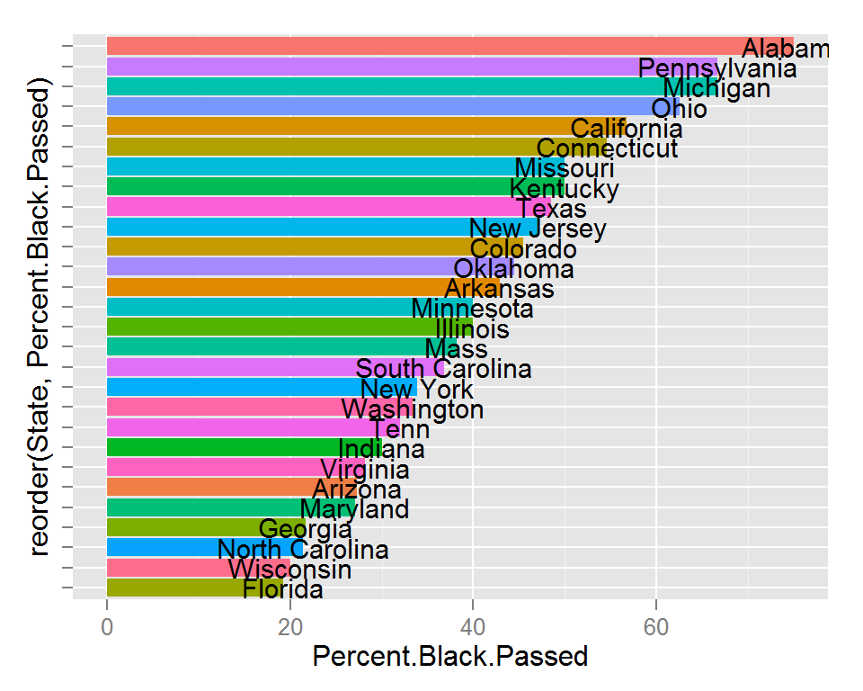

```r
ggplot(BlackPercentage, aes(x = reorder(State, Percent.Black.Passed),
    y = Percent.Black.Passed, group = State, fill = State)) +
    geom_bar(stat = "identity") + theme(legend.position = "none",
    axis.text.y = element_blank()) + geom_text(aes(label = State),
    size = 4) + coord_flip()
```

```r
# Bar Plot of Passing percentage, in descending order, by
# state
BlackPercentageBar <- gvisBarChart(BlackPercentage[order(-BlackPercentage$Percent.Black.Passed),
    ], xvar = "State", yvar = "Percent.Black.Passed", options = list(width = 800,
    height = 800))
# plot(BlackPercentageBar)
print(BlackPercentageBar, file = "blackpercentagebar.html")
```

[interactive chart not shown]

This is a graph of that Data frame, showing a bar chart of passing rates by state.

```r
p1 <- ggplot(BlackPercentage, aes(x = Percent.Black.Passed, y = numblack.taking.exam)) +
    geom_point() + geom_smooth(color = "black", method = lm)
# scatterplot of Percentage Passed and Percentage taken in
# each state, with regression line
p1set <- BlackPercentage %>% select(8, 9)
p1gvis <- gvisScatterChart(p1set, options = list(width = 800,
    height = 800, pointSize = 5))
# plot(p1gvis)
print(p1gvis, file = "p1gvis.html")


p2 <- ggplot(BlackPercentage, aes(x = Percent.Black.Passed, y = TeacherYield)) +
    geom_point() + geom_smooth(color = "black", method = lm)
# scatterplot of Percentage Passed and Teacher Yield in each
# state, with regression line
p2set <- BlackPercentage %>% select(8, 2)
p2gvis <- gvisScatterChart(p2set, options = list(width = 800,
    height = 800, pointSize = 5))
# plot(p2gvis)
print(p2gvis, file = "p2gvis.html")
```

[interactive chart not shown]

These are both scatter plots, showing the relationship between Black percentage passing, and number taking the exam in the first graph, and the teacher to student ratio in the second graph. In the first scatter plot, we found similarities with the Hispanic students and the Female students, in that the more students taking, the worse they did. We thought this may be due to less individual attention by the teachers, and this is why we ran the second graph, or the teacher yield.

## Female Students

```r
GirlPercentage <- APcomputercleaned2013 %>% select(1, 29, 7:10) %>%
    filter(numfemale.passed != "*", numfemale != "0")
# Data Frame
GirlPercentage$Percentfemalepassed <- as.numeric(as.character(GirlPercentage$percentfemale.passed))
# factor to numeric
GirlPercentage$PercentFemaleTaking <- as.numeric(as.character(GirlPercentage$percentfemale))
```

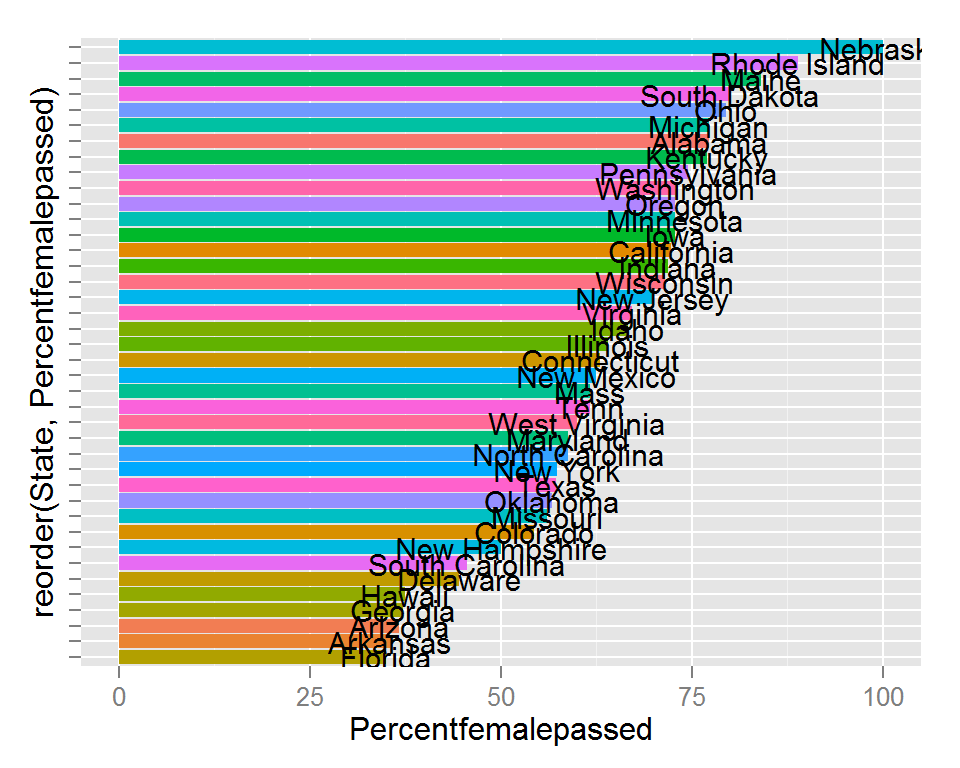

```r
ggplot(GirlPercentage, aes(x = reorder(State, Percentfemalepassed),
    y = Percentfemalepassed, group = State, fill = State)) +
    geom_bar(stat = "identity") + theme(legend.position = "none",
    axis.text.y = element_blank()) + geom_text(aes(label = State),
    size = 4) + coord_flip()
```

```r
# Bar Plot of Passing percentage, in descending order, by
# state
GirlPercentageBar <- gvisBarChart(GirlPercentage[order(-GirlPercentage$Percentfemalepassed),
    ], xvar = "State", yvar = "Percentfemalepassed", options = list(width = 800,
    height = 800))
# plot(GirlPercentageBar)
print(GirlPercentageBar, file = "girlpercentagebar.html")
```

[interactive chart not shown]

We created the same plot for Females as we did with Blacks, and created a similar data frame to do so.

```r
p3 <- ggplot(GirlPercentage, aes(x = Percentfemalepassed, y = percentfemale)) +
    geom_point() + geom_smooth(color = "black", method = lm)
# scatterplot of Percentage Passed and Percentage taken in
# each state, with regression line
p3set <- GirlPercentage %>% select(7, 8)
p3gvis <- gvisScatterChart(p3set, options = list(width = 800,
    height = 800, pointSize = 5))
# plot(p3gvis)
print(p3gvis, file = "p3gvis.html")


p4 <- ggplot(GirlPercentage, aes(x = Percentfemalepassed, y = TeacherYield)) +
    geom_point() + geom_smooth(color = "black", method = lm)
# scatterplot of Percentage Passed and Teacher Yield in each
# state, with regression line
p4set <- GirlPercentage %>% select(7, 2)
p4gvis <- gvisScatterChart(p4set, options = list(width = 800,
    height = 800, pointSize = 5))
# plot(p4gvis)
print(p4gvis, file = "p4gvis.html")
```

[interactive chart not shown]

Looking at these last two graphs, you can see the correlation here as we saw in the Black percentage section.

## Hispanic Students

```r
HispanicPercentage <- APcomputercleaned2013 %>% select(1, 29,
    20:22, 26) %>% filter(percentHispanic.passed != "*", percentHispanic.passed !=
    "0", percentHispanic.passed != "NA")
# Data Frame
HispanicPercentage$PercentHispanicpassed <- as.numeric(as.character(HispanicPercentage$percentHispanic.passed))
# factor to numeric
HispanicPercentage$PercentHispanicTaken <- as.numeric(as.character(HispanicPercentage$percent.hispanic.taking.exam))
```

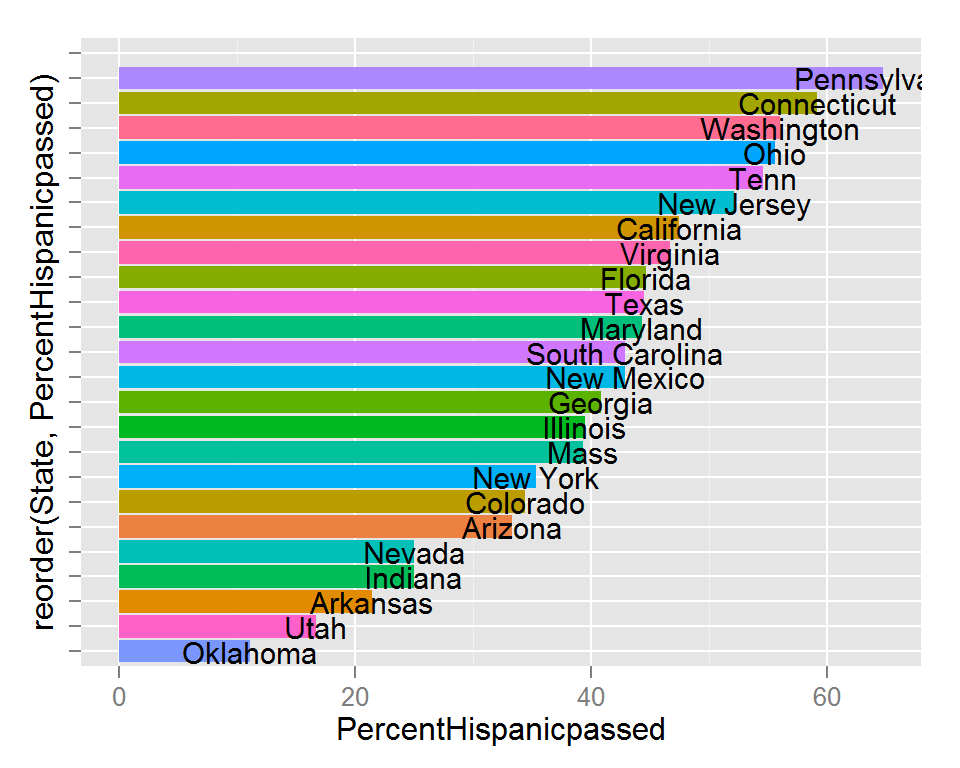

```r
ggplot(HispanicPercentage, aes(x = reorder(State, PercentHispanicpassed),
    y = PercentHispanicpassed, group = State, fill = State)) +
    geom_bar(stat = "identity") + theme(legend.position = "none",
    axis.text.y = element_blank()) + geom_text(aes(label = State),
    size = 4) + coord_flip()
```

```r
# Bar Plot of Passing percentage, in descending order, by
# state
HispanicPercentageBar <- gvisBarChart(HispanicPercentage[order(-HispanicPercentage$PercentHispanicpassed),
    ], xvar = "State", yvar = "PercentHispanicpassed", options = list(width = 800,
    height = 800))
# plot(HispanicPercentageBar)
print(HispanicPercentageBar, file = "hispanicpercentagebar.html")
```

[interactive chart not shown]

Bar chart by state for Hispanic Students

```r
p5 <- ggplot(HispanicPercentage, aes(x = PercentHispanicpassed,
    y = percent.hispanic.taking.exam)) + geom_point() + geom_smooth(color = "black",
    method = lm)
# scatterplot of Percentage Passed and Percentage taken in
# each state, with regression line
p5set <- HispanicPercentage %>% select(7, 8)
p5gvis <- gvisScatterChart(p5set, options = list(width = 800,
    height = 800, pointSize = 5))
# plot(p5gvis)
print(p5gvis, file = "p5gvis.html")


p6 <- ggplot(HispanicPercentage, aes(x = PercentHispanicpassed,
    y = TeacherYield)) + geom_point() + geom_smooth(color = "black",
    method = lm)
# scatterplot of Percentage Passed and Teacher Yield in each
# state, with regression line
p6set <- HispanicPercentage %>% select(7, 2)
p6gvis <- gvisScatterChart(p6set, options = list(width = 800,
    height = 800, pointSize = 5))
# plot(p6gvis)
print(p6gvis, file = "p6gvis.html")
```

[interactive chart not shown]

Oddly enough, the teacher yield for Hispanic students is different than with the other two groups. While this may show for a small case, I would have to think that past a certain yield, the results would eventually decline.

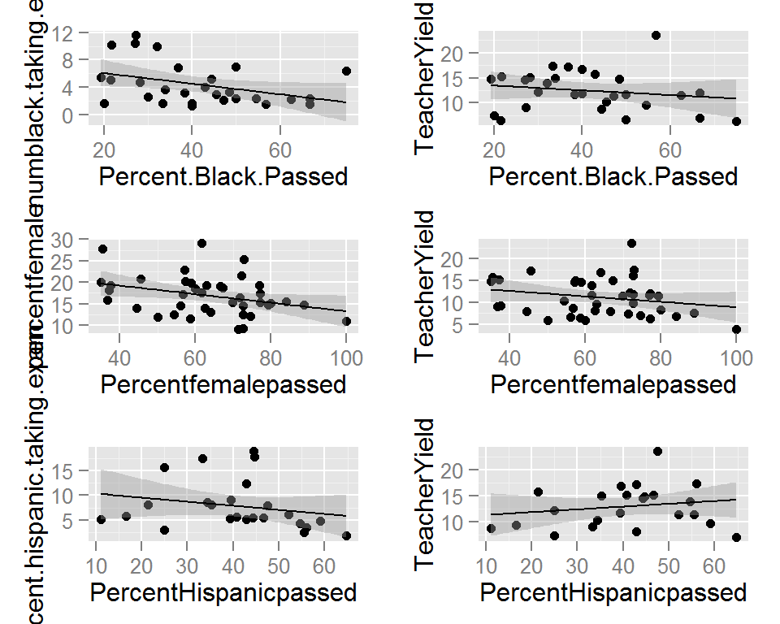

```r
grid.arrange(p1, p2, p3, p4, p5, p6, ncol = 2)
```

This is a grid using ggplot2 showing the last graphs side by side, for Black, Female, and Hispanic students. With the regression lines, you can see how the trend for teacher yield and students taking exam really works. This just shows how similar the graphs are for Black and Female students, and how odd it is for the Hispanic students.

## Geostates

```r
GeoStatesBlack <- gvisGeoChart(BlackPercentage, "State", "Percent.Black.Passed",
    options = list(region = "US", displayMode = "regions", resolution = "provinces",
        width = 600, height = 400))
# plot(GeoStatesBlack)
print(GeoStatesBlack, file = "GeoStatesBlack.html")



GeoStatesGirl <- gvisGeoChart(GirlPercentage, "State", "Percentfemalepassed",
    options = list(region = "US", displayMode = "regions", resolution = "provinces",
        width = 600, height = 400))
# plot(GeoStatesGirl)
print(GeoStatesGirl, file = "GeoStatesGirl.html")



GeoStatesHispanic <- gvisGeoChart(HispanicPercentage, "State",
    "PercentHispanicpassed", options = list(region = "US", displayMode = "regions",
        resolution = "provinces", width = 600, height = 400))
# plot(GeoStatesHispanic)
print(GeoStatesHispanic, file = "GeoStatesHispanic.html")
```

[interactive chart not shown]

These three graphs show the pass rates by geographical location of the state; a full white result means the test was not taken there. Some of these numbers should be taken with a grain of salt; some states may have only had ten people take the test, while states such as California had hundreds.